# Day 1. Basic R Manipulation

by Zuguang Gu (z.gu@dkfz.de), 2017-12-13 09:01:00. The github repository for this material is at https://github.com/eilslabs/teaching.

# Basic data format

There are following basic data types in R: vectors, matrices, data frames and lists. See https://www.statmethods.net/input/datatypes.html for explanation.

### task

Constuct a numeric vector from 1 to 10.

### solution

```r
x = 1:10
x
```

```
##  [1]  1  2  3  4  5  6  7  8  9 10
```

### task

Constuct a numeric vector of 3, 6, 2, 9, 1.

### solution

```r
x = c(3, 6, 2, 9, 1)
x
```

```
## [1] 3 6 2 9 1
```

### task

Constuct a character vector of weekdays in a week, then extract the weekdays for the weekend.

### solution

```r
x = c("Monday", "Tuesday", "Wendesday", "Thursday", "Friday", "Saturday", "Sunday")
x
```

```
## [1] "Monday"    "Tuesday"   "Wendesday" "Thursday"  "Friday"    "Saturday"
## [7] "Sunday"
```

```r
x[6:7]
```

```
## [1] "Saturday" "Sunday"
```

### task

Constuct a numeric vector of the time at which you wake up in the morning everyday in a week and use weekdays as names of the vector, then extract the two days in the weekend.

### solution

```r
# solution 1:
x = c("Monday" = 7, "Tuesday" = 7, "Wendesday" = 8, "Thursday" = 9, "Friday" = 8, "Saturday" = 12, "Sunday" = 12)
x
```

```
##    Monday   Tuesday Wendesday  Thursday    Friday  Saturday    Sunday
##         7         7         8         9         8        12        12
```

```r
# solution 2:
x = c(7, 7, 8, 9, 8, 12, 12)
names(x) = c("Monday", "Tuesday", "Wendesday", "Thursday", "Friday", "Saturday", "Sunday")
x
```

```
##    Monday   Tuesday Wendesday  Thursday    Friday  Saturday    Sunday
##         7         7         8         9         8        12        12
```

```r
x[6:7] # or
```

```
## Saturday   Sunday
##       12       12
```

```r
x[c("Saturday", "Sunday")]
```

```
## Saturday   Sunday
##       12       12
```

### task

Construct a matrix of random values with 10 rows and 5 columns.

Consider `rnorm()`, `sample()`, `runif()` for random value generation. If you don’t knonw how to use these functions, type `?rnorm`, `?sample` and `?runif` for documentations.

### solution

```r
m = matrix(rnorm(50), nrow = 10)
m = matrix(runif(50), nrow = 10)
m = matrix(sample(10, 10, replace = TRUE), nrow = 10)
```

### task

Construct a data frame of monthly climate statistics in Heidelberg (https://en.wikipedia.org/wiki/Heidelberg#collapsibleTable0).

### solution

```r
climate = data.frame(
    average_high  = c(3.8, 6.1, 10.9, 15.4, 19.9, 23, 25.5, 25.1, 21.5, 15.3, 8.5, 4.8),
    daily_mean    = c(2.4, 3.7, 7.4, 11.2, 15.5, 18.1, 20.6, 20.1, 16.1, 11.5, 6.3, 3.3),
    average_low   = c(-1.4, -0.7, 1.9, 4.9, 8.9, 12.2, 14, 13.8, 10.6, 6.7, 2.4, -0.4),
    precipitation = c(56, 53, 53, 61, 79, 86, 71, 66, 53, 58, 66, 66),
    sunshine      = c(46, 78, 118, 173, 206, 215, 233, 219, 157, 101, 50, 35)
)
rownames(climate) = c("Jan", "Feb", "Mar", "Apr", "May", "Jun", "Jul", "Aug", "Sep", "Oct", "Nov", "Dec")
```

Note: we will use `climate` variable in later tasks.

### task

Construct a list which contains dates in each month this year.

Construct a list which contains some of the following description of yourself:

- name (character)
- age (numeric)
- interest (more than one)
- do you like programming (the value should be logical)

### solution

```r
date = list(
    Jan = 1:31,
    Feb = 1:28,
    Mar = 1:31,
    Apr = 1:30,
    May = 1:31,
    Jun = 1:30,
    Jul = 1:31,
    Aug = 1:31,
    Sep = 1:30,
    Oct = 1:31,
    Nov = 1:30,
    Dec = 1:31
)

me = list(
    name = "Zuguang Gu",
    age = 34,
    interest = c("movie", "game"),
    like_programming = TRUE
)
me
```

```
## $name
## [1] "Zuguang Gu"
##
## $age
## [1] 34
##
## $interest
## [1] "movie" "game"
##
## $like_programming
## [1] TRUE
```

```r
me$name
```

```
## [1] "Zuguang Gu"
```

# Read and write tables from/to files

The most common file format for data importing and exporing in R is table-like data in text format (e.g. tsv or csv format). There can also be other formats like Excel format (xls or xlsx format) or database format (e.g. sql format). Please refer to https://www.statmethods.net/input/importingdata.html for explanation.

### task

Save `climate` as a csv file.

save `climate` as a tab-separated file.

### solution

```r
write.csv(climate, file = "climate.csv")
write.table(climate, sep = "\t", quote = FALSE, file = "climate.tab")
```

### task

Read climate data back to R.

### solution

```r
df = read.csv("climate.csv", header = TRUE, row.names = 1)
df = read.table("climate.tab", header = TRUE, row.names = 1)
```

# Control structure

Control struction is a basic feature for all programming languages, which basically includes `for`, `if-else` and `while`.

### task

Only show the dates for the month with 31 days.

### solution

```r
month_name = names(date)
for(i in seq_along(date)) {
    if(length(date[[i]]) == 31) {
        cat(month_name[i], "has 31 days.\n")
    }
}
```

```
## Jan has 31 days.
## Mar has 31 days.
## May has 31 days.
## Jul has 31 days.
## Aug has 31 days.
## Oct has 31 days.
## Dec has 31 days.
```

# Descriptive statistics

### task

With `climate`, calcualte the mean/median/sd/ of each column:

### solution

```r
mean(climate$average_high)
```

```
## [1] 14.98333
```

```r
mean(climate$daily_mean)
```

```
## [1] 11.35
```

```r
mean(climate$precipitation)
```

```
## [1] 64
```

```r
# or calculate statistics for all columns at a same time
apply(climate, 2, mean)
```

```
##  average_high    daily_mean   average_low precipitation      sunshine
##      14.98333      11.35000       6.07500      64.00000     135.91667
```

```r
apply(climate, 2, median)
```

```
##  average_high    daily_mean   average_low precipitation      sunshine
##         15.35         11.35          5.80         63.50        137.50
```

```r
apply(climate, 2, sd)
```

```
##  average_high    daily_mean   average_low precipitation      sunshine
##      8.036941      6.688185      5.759281     10.625869     73.768013
```

### task

Does temporature correlates to the precipitation or sunshine?

### solution

```r
cor(climate$daily_mean, climate$precipitation)
```

```
## [1] 0.5286887
```

```r
cor(climate$daily_mean, climate$sunshine)
```

```
## [1] 0.9404352
```

### task

Does the precipitation in May, June, July, Octorber, September and Octorber has difference to to other monthe?

### solution

```r
precipitation = climate$precipitation
t.test(precipitation[5:10],
       precipitation[c(1:4, 11:12)])
```

```
##
##  Welch Two Sample t-test
##
## data:  precipitation[5:10] and precipitation[c(1:4, 11:12)]
## t = 1.7074, df = 7.2249, p-value = 0.1302
## alternative hypothesis: true difference in means is not equal to 0
## 95 percent confidence interval:
##  -3.637248 22.970582
## sample estimates:
## mean of x mean of y
##  68.83333  59.16667
```

# Graphics

R is convinient to make complex graphics for representing complex relations in users’ datasets, but the mostly used graphics are still those basic graphics like scatter plot or barplot which gives a quick view of the patterns in the data.

### task

Plot the daily mean temporature in `climate` as barplot.

### solution

Type `?par` to see the meaning of `las =3`.

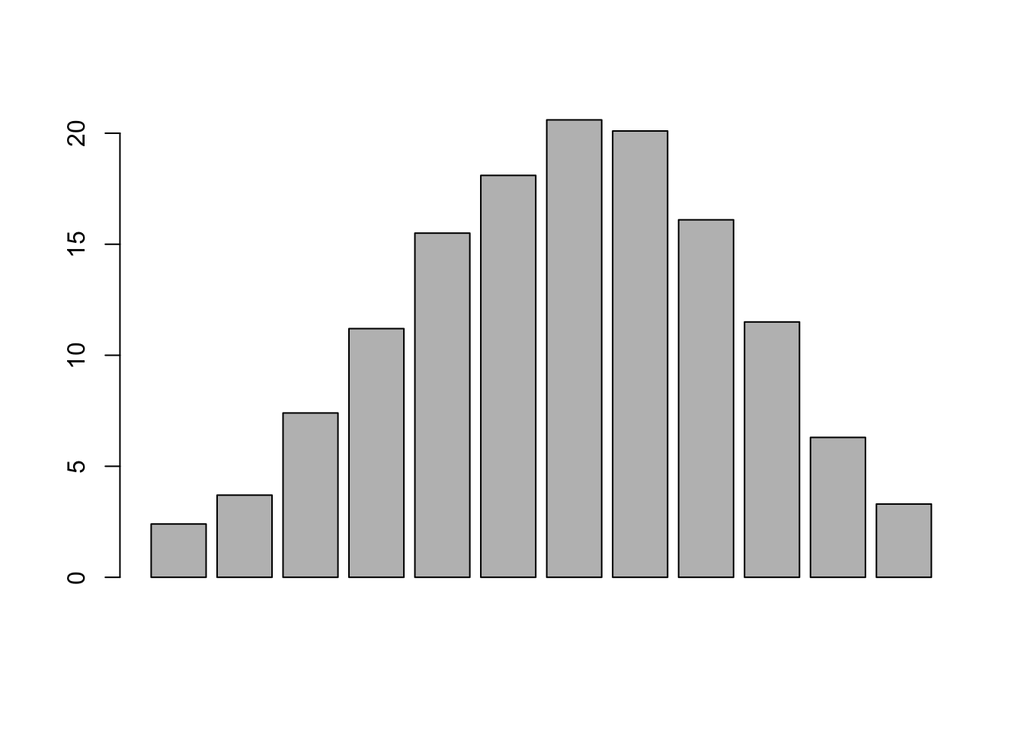

```r
barplot(climate$daily_mean)
```

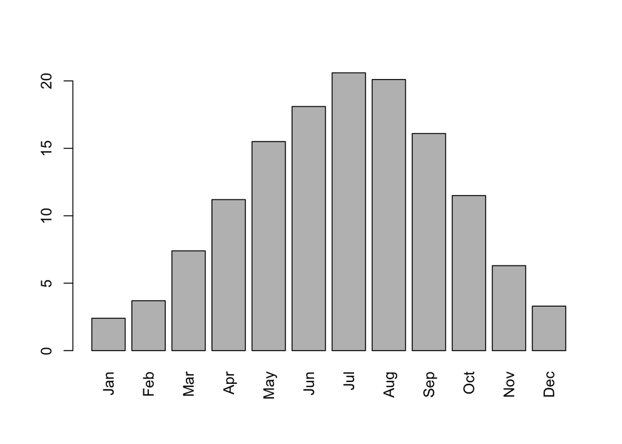

```r
par(las = 3)
barplot(climate$daily_mean, names.arg = rownames(climate))
```

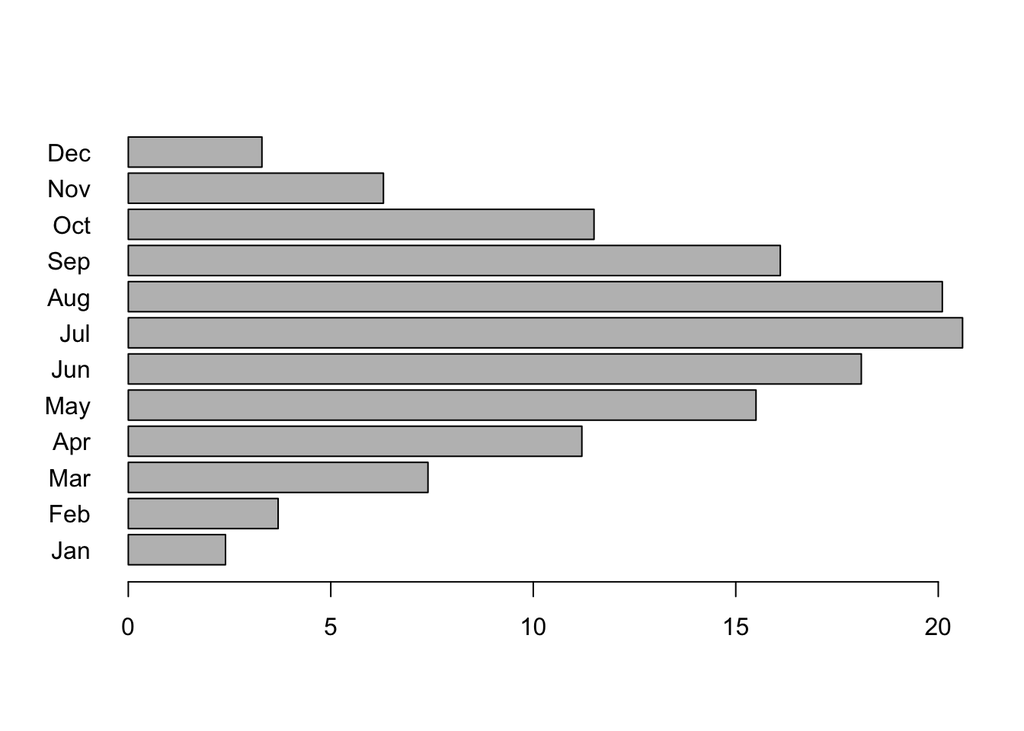

```r
par(las = 0)

par(las = 1)
barplot(climate$daily_mean, names.arg = rownames(climate), horiz = TRUE)
```

```r
par(las = 0)
```

### task

Plot `average_high`, `daily_mean` and `average_low` as boxplot to see the differences between these three statistics.

### solution

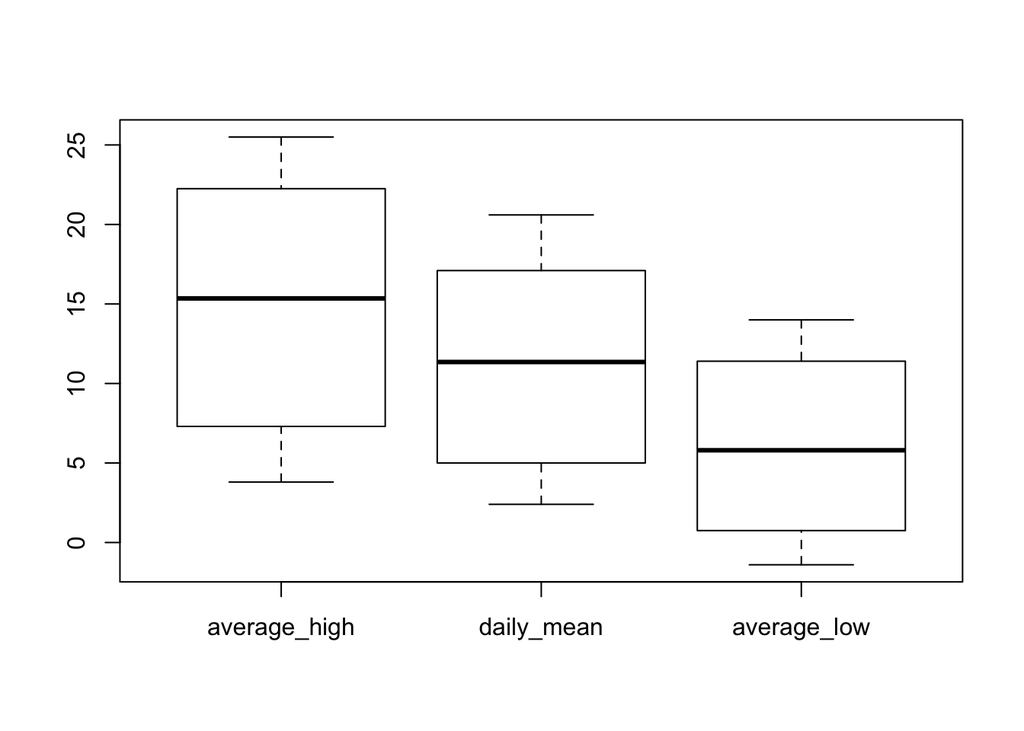

```r
boxplot(climate[, 1:3])
```

### task

Plot the five statistics in `climate` in a same page (by barplots, point plots or line plots).

### solution

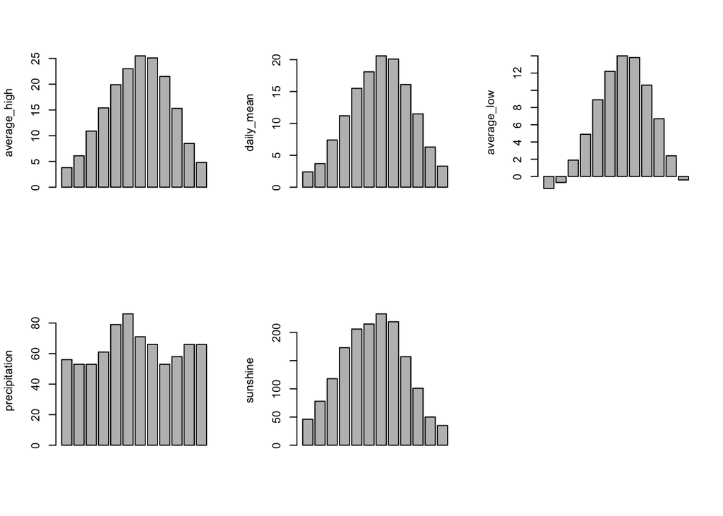

```r
par(mfrow = c(2, 3))
stat_name = colnames(climate)
for(i in 1:5) {
    barplot(climate[, i], ylab = stat_name[i])
}
par(mfrow = c(1, 1))
```

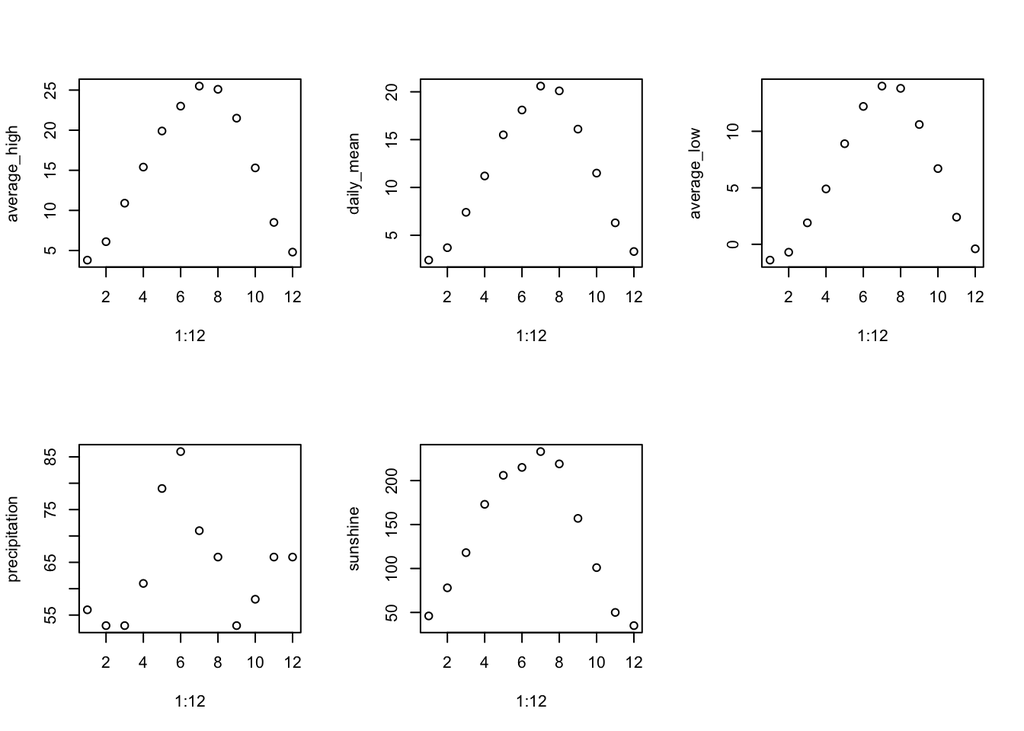

```r
# by points
par(mfrow = c(2, 3))
stat_name = colnames(climate)
for(i in 1:5) {
    plot(1:12, climate[, i], ylab = stat_name[i])
}
par(mfrow = c(1, 1))
```

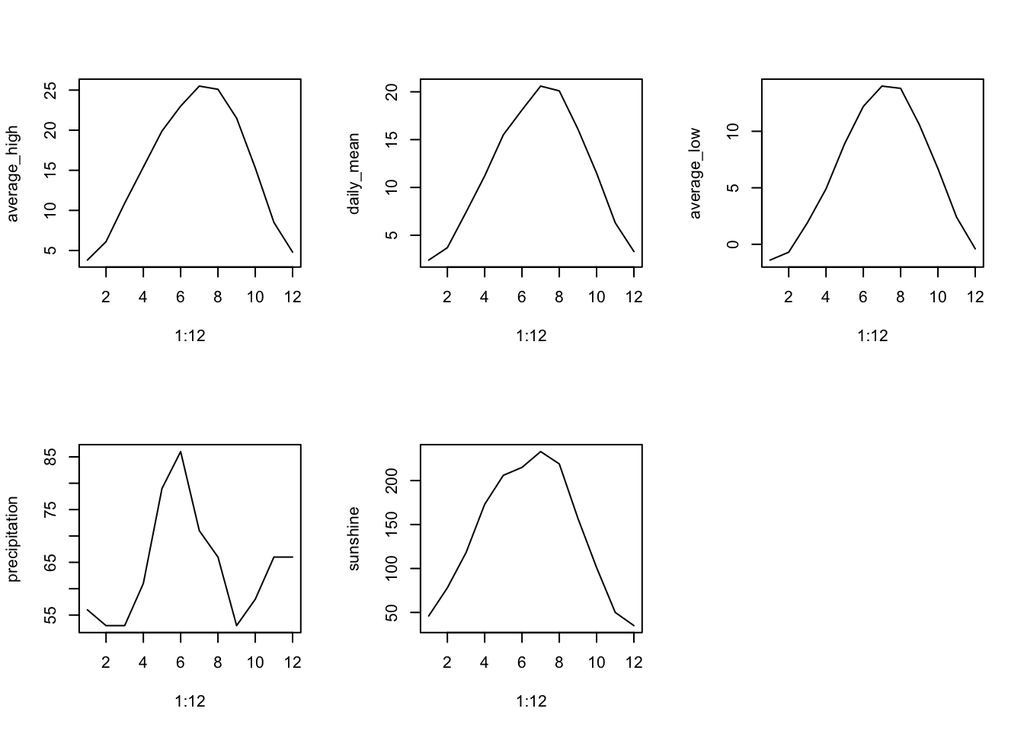

```r
# by lines
par(mfrow = c(2, 3))
stat_name = colnames(climate)
for(i in 1:5) {
    plot(1:12, climate[, i], type = "l", ylab = stat_name[i])
}
par(mfrow = c(1, 1))
```

### task

Make pair-wise scatter plots for the five statistics in `climate`:

### solution

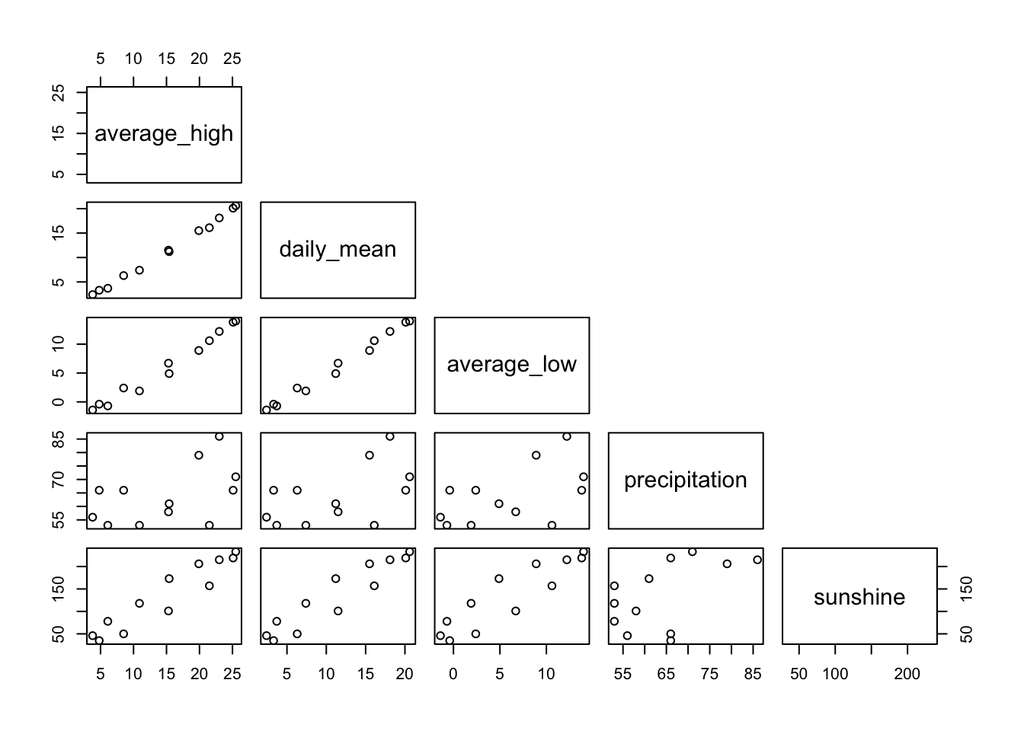

```r
pairs(climate, upper.panel = NULL)
```

### task

From above plot, we found an interesting pattern between temporature and sunshine. To better reveal the potential reason for this special pattern, we add month names as text to the points in the plot. Can you explain the pattern in the plot?

### solution

Recall the correlation between `daily_mean` and `sunshine` is very high, but according to following plot, do you still think the correlation is just a simple linear correlation or there are something complex which is hidden by the correlation coefficient?

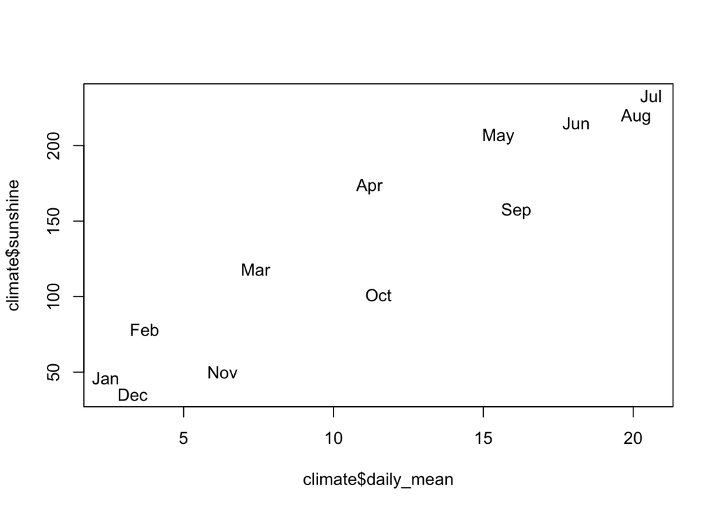

```r
plot(climate$daily_mean, climate$sunshine, type = "n")
text(climate$daily_mean, climate$sunshine, rownames(climate))
```

We do similar for precipitation and sunsine

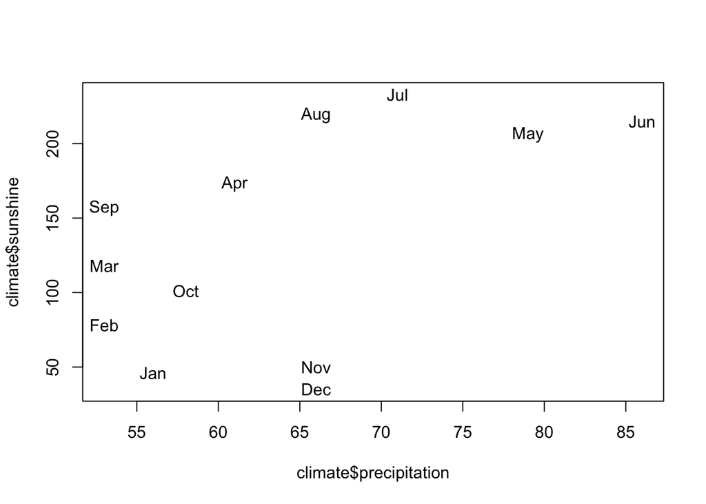

```r
plot(climate$precipitation, climate$sunshine, type = "n")
text(climate$precipitation, climate$sunshine, rownames(climate))
```